# Stat425 HW01

Yu Wu

2/3/2020

## R Markdown

**1. Problem 1:** The data set prostate from the faraway library, is from a study on 97 men with who were due to receive a radical prostatectomy. Make a numerical and graphical summary of the data. Comment on your results.

```r
library(faraway)
library(ggplot2)
summary(prostate)
```

```
##      lcavol           lweight           age             lbph
##  Min.   :-1.3471   Min.   :2.375   Min.   :41.00   Min.   :-1.3863
##  1st Qu.: 0.5128   1st Qu.:3.376   1st Qu.:60.00   1st Qu.:-1.3863
##  Median : 1.4469   Median :3.623   Median :65.00   Median : 0.3001
##  Mean   : 1.3500   Mean   :3.653   Mean   :63.87   Mean   : 0.1004
##  3rd Qu.: 2.1270   3rd Qu.:3.878   3rd Qu.:68.00   3rd Qu.: 1.5581
##  Max.   : 3.8210   Max.   :6.108   Max.   :79.00   Max.   : 2.3263
##       svi              lcp             gleason          pgg45
##  Min.   :0.0000   Min.   :-1.3863   Min.   :6.000   Min.   :  0.00
##  1st Qu.:0.0000   1st Qu.:-1.3863   1st Qu.:6.000   1st Qu.:  0.00
##  Median :0.0000   Median :-0.7985   Median :7.000   Median : 15.00
##  Mean   :0.2165   Mean   :-0.1794   Mean   :6.753   Mean   : 24.38
##  3rd Qu.:0.0000   3rd Qu.: 1.1786   3rd Qu.:7.000   3rd Qu.: 40.00
##  Max.   :1.0000   Max.   : 2.9042   Max.   :9.000   Max.   :100.00
##       lpsa
##  Min.   :-0.4308
##  1st Qu.: 1.7317
##  Median : 2.5915
##  Mean   : 2.4784
##  3rd Qu.: 3.0564
##  Max.   : 5.5829
```

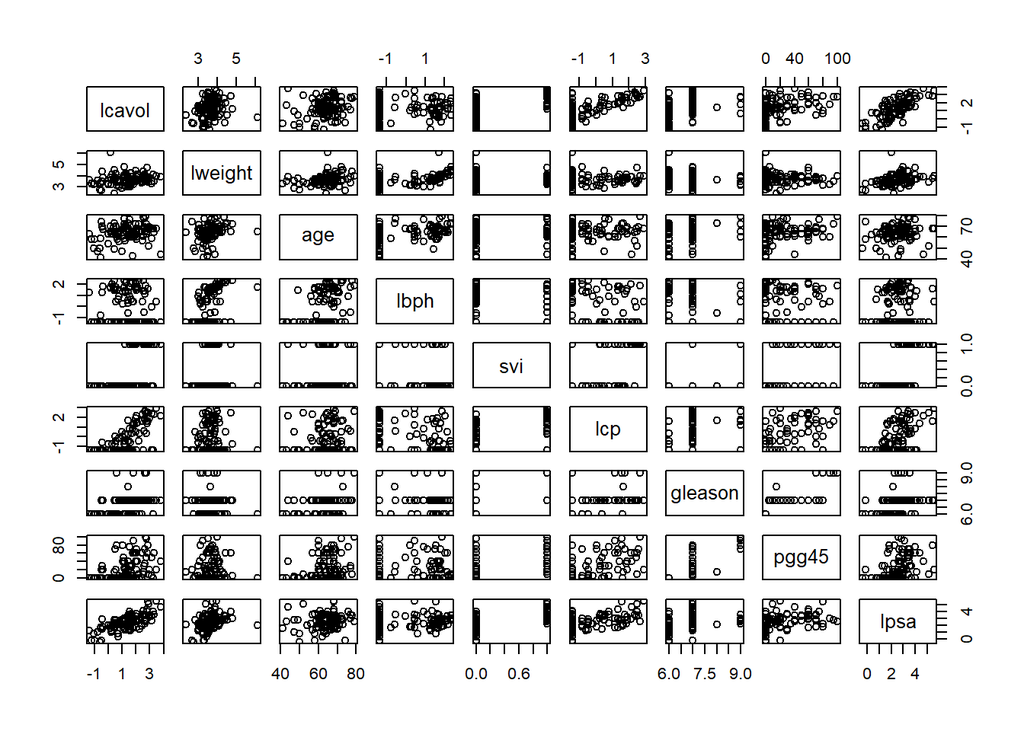

```r
pairs(prostate)
```

**2. Problem 2:** Show that for the SLR model, the coefficient of determination $R^2$ is equal to the square of the correlation coefficient $r_{XY}^2$.

$$\begin{equation}
\begin{split}
R^2 &= \frac{FSS}{TSS} \\
&= \frac{\Sigma(\hat{y}-\bar{y})^2}{\Sigma(\bar{x}-\bar{x})^2} \\
\\
\hat{y_i} &= \hat{\beta_0}+\hat{\beta_1x_i} \\
\\
\hat{\beta_0} &= \bar{y}-\hat{\beta_1\bar{x}} \\
\\
\hat{\beta_1} &= \frac{S_{XY}}{S_{XX}} \\
&= \frac{\Sigma(x_i-\bar{x})\Sigma(y_i-\bar{y})}{\Sigma(x_i-\bar{x})^2} \\
\\
\Sigma(\hat{y_i}-\bar{y})^2 &= \Sigma(\hat{\beta_0}+\hat{\beta_1}x_i-\bar{y})^2 \\
&= \Sigma{\bar{y}-\hat{\beta_1}\bar{x}+\hat{\beta_1}x_i-\bar{y}} \\
&= \hat{\beta_1}^2\Sigma(x_i-\bar{x})^2 \\
&= \frac{[\Sigma(x_i-\bar{x})\Sigma(y_i-\bar{y})]^2}{[\Sigma(x_i-\bar{x})^2]^2} \Sigma(x_i-\bar{x})^2 \\
&= \frac{[\Sigma(x_i-\bar{x})\Sigma(y_i-\bar{y})]^2}{\Sigma(x_i-\bar{x})^2} \\
\\
R^2 &= \frac{\Sigma(\hat{y}-\bar{y})^2}{\Sigma(\bar{x}-\bar{x})^2} \\
&= \frac{[\Sigma(x_i-\bar{x})\Sigma(y_i-\bar{y})]^2}{\Sigma(x_i-\bar{x})^2 \Sigma(y_i-\bar{y})^2} \\
&= \frac{S_{XY}^2}{S_{XX}S_{YY}} \\
&= r_{XY}^2
\end{split}
\end{equation}$$

**3. Problem 3:** The manager of the purchasing department of a large company would like to develop a regression model to predict the average amount of time it takes to process a given number of invoices. Over a 30-day period, data are collected on the number of invoices processed and the total time taken (in hours). The data are available in the file invoices.txt. The following model was fit to the data: Y = β0 + β1x + e, where Y is the processing time and x is the number of invoices.

1. Plot the data and comment on the results.

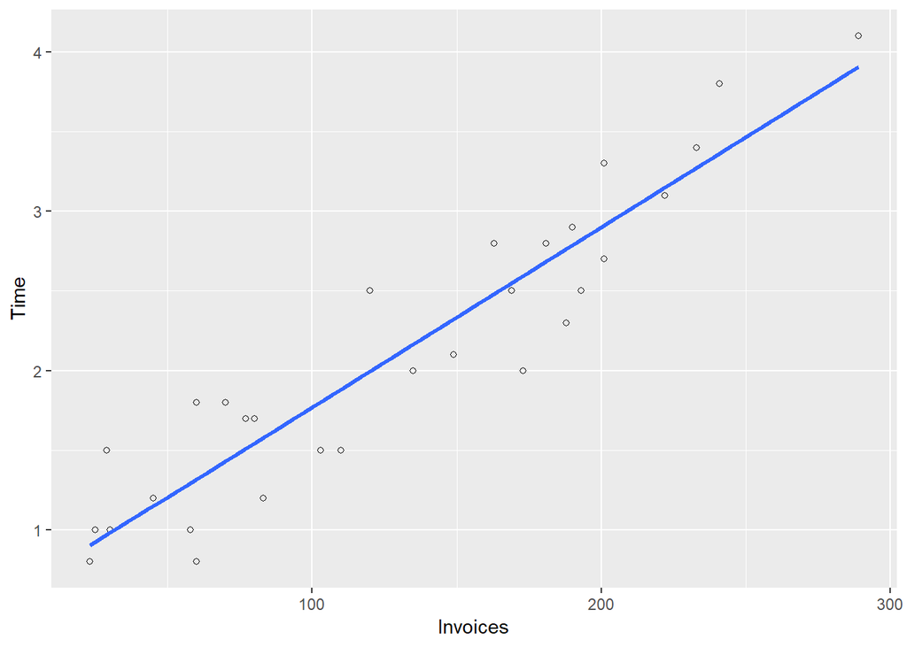

```r
invoice <- read.table('invoices.txt', header = TRUE)

ggplot(invoice, aes(Invoices,Time)) + geom_point(shape=1) +
  geom_smooth(method=lm, se=FALSE, lwd=1.2)
```

The ls model fits the dataset well.

2. Find a 95% confidence interval for the start-up time, ie., β0.

```r
out <- lm(Time~Invoices, data = invoice)
summary(out)
```

```
##
## Call:
## lm(formula = Time ~ Invoices, data = invoice)
##
## Residuals:
##      Min       1Q   Median       3Q      Max
## -0.59516 -0.27851  0.03485  0.19346  0.53083
##
## Coefficients:
##              Estimate Std. Error t value Pr(>|t|)
## (Intercept) 0.6417099  0.1222707   5.248 1.41e-05 ***
## Invoices    0.0112916  0.0008184  13.797 5.17e-14 ***
## ---
## Signif. codes:  0 '***' 0.001 '**' 0.01 '*' 0.05 '.' 0.1 ' ' 1
##
## Residual standard error: 0.3298 on 28 degrees of freedom
## Multiple R-squared:  0.8718, Adjusted R-squared:  0.8672
## F-statistic: 190.4 on 1 and 28 DF,  p-value: 5.175e-14
```

```r
predict(out, newdata=data.frame(Invoices = 0), interval="confidence")
```

```
##         fit       lwr       upr
## 1 0.6417099 0.3912496 0.8921701
```

3. Suppose that a best practice benchmark for the average processing time for an additional invoice is 0.01 hours (pr. 0.6 minutes). Test the null hypothesis H0 : β1 = 0.01 against a two-sided alternative. Interpret your result.

```r
confint(out, 'Invoices', levels=0.95)
```

```
##                2.5 %     97.5 %
## Invoices 0.009615224 0.01296806
```

The value of $\beta_1$ of $H_0$ is in the confidence interval thus we do not reject the null hypothesis.

4. Find a point estimate and a 95% prediction interval for the time taken to process 130 invoices.

```r
predict(out, newdata=data.frame(Invoices = 130), interval="prediction")
```

```
##        fit      lwr    upr
## 1 2.109624 1.422947 2.7963
```

**5. Problem 5:** A story by James R. Hagerty entitled With Buyers Sidelined, Home Prices Slide published in the Thursday October 25, 2007 edition of the Wall Street Journal contained data on so-called fundamental housing indicators in major real estate markets across the US. The author argues that. . . prices are generally falling and overdue loan payments are piling up. Thus, we shall consider data presented in the article on: Y = Percentage change in average price from July 2006 to July 2007 (based on the S& P/CaseShiller national housing index); and x= Percentage of mortgage loans 30 days or more overdue in latest quarter (based on data from Equifax and Moody’s). The data are available in the file indicators.txt. Fit the following model to the data: Y = β0 + β1x + e. Complete the following tasks:

1. Calculate the R2 and adjusted R2 for the SLR model. Provide an interpretation of both quantities.

```r
indicators <- read.table('indicators.txt', header = TRUE)
out <- lm(PriceChange~LoanPaymentsOverdue, data = indicators)
summary(out)
```

```
##
## Call:
## lm(formula = PriceChange ~ LoanPaymentsOverdue, data = indicators)
##
## Residuals:
##     Min      1Q  Median      3Q     Max
## -4.6541 -3.3419 -0.6944  2.5288  6.9163
##
## Coefficients:
##                     Estimate Std. Error t value Pr(>|t|)
## (Intercept)           4.5145     3.3240   1.358   0.1933
## LoanPaymentsOverdue  -2.2485     0.9033  -2.489   0.0242 *
## ---
## Signif. codes:  0 '***' 0.001 '**' 0.01 '*' 0.05 '.' 0.1 ' ' 1
##
## Residual standard error: 3.954 on 16 degrees of freedom
## Multiple R-squared:  0.2792, Adjusted R-squared:  0.2341
## F-statistic: 6.196 on 1 and 16 DF,  p-value: 0.02419
```

```r
summary(out)$r.sq
```

```
## [1] 0.2791527
```

```r
summary(out)$adj.r
```

```
## [1] 0.2340997
```

2. Find a 95% confidence interval for the slope of the regression model, β1 . On the basis of this confidence interval decide whether there is evidence of a significant negative linear association.

```r
confint(out, 'LoanPaymentsOverdue', level = 0.95)
```

```
##                         2.5 %     97.5 %
## LoanPaymentsOverdue -4.163454 -0.3335853
```

3. Use the fitted regression model to estimate E(Y |X = 4). Find a 95% confidence interval for E(Y |X = 4). Is 0% a feasible value for E(Y |X = 4)? Give a reason to support your answer.

```r
predict(out, data.frame(LoanPaymentsOverdue = 4), interval="confidence")
```

```
##         fit       lwr       upr
## 1 -4.479585 -6.648849 -2.310322
```

0% is not a feasible value because it is not in the confidence interval.